# Boca Ciega Bay Aquatic Preserve

# Oyster

The data file used is: **All_OYSTER_Parameters-2026-Jun-04.txt**

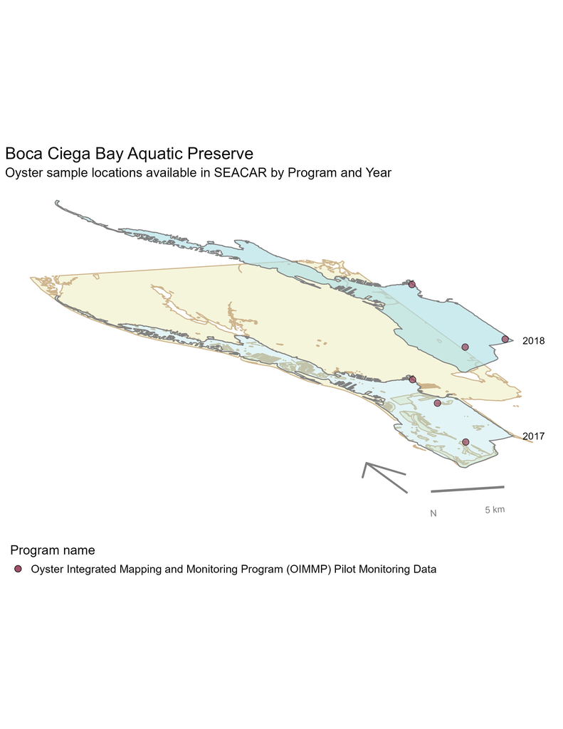

Maps showing the temporal scope of oyster sampling sites within the boundaries of *Boca Ciega Bay Aquatic Preserve* by program name.

Click [here](https://github.com/FloridaSEACAR/SEACAR_Trend_Analyses/tree/main/Oyster/output/Oyster_temporal_scope_plots) to view spatio-temporal plots on GitHub.

## Density

For natural reefs, there was insufficient data to calculate a trend for density.

### Natural

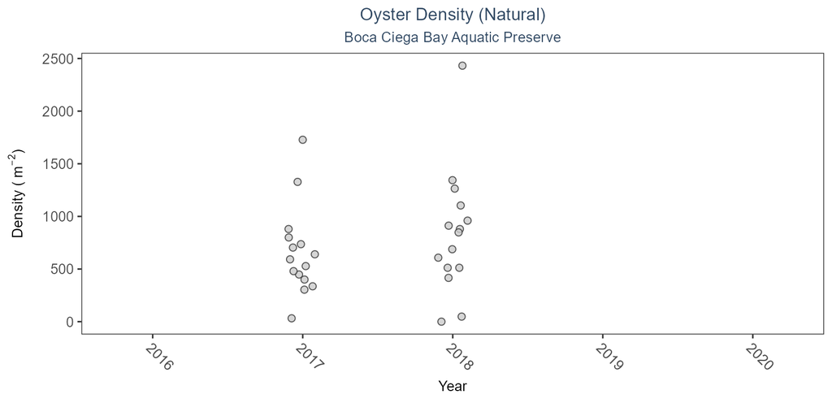

Scatter plot of oyster density over time. If the time series included five or more years with observations, an estimated trend (blue line) and a 95% credible interval (purple band) may also be plotted. Data points are jittered horizontally to reduce overlap.

Model results for Oyster Density - Natural

| Habitat Type | Shell Type | Statistical Trend | Period of Record | Estimate | Standard Error | Credible Interval |
| --- | --- | --- | --- | --- | --- | --- |
| Natural | Live Oysters | Insufficient data | 2017 - 2018 | - | - | - |

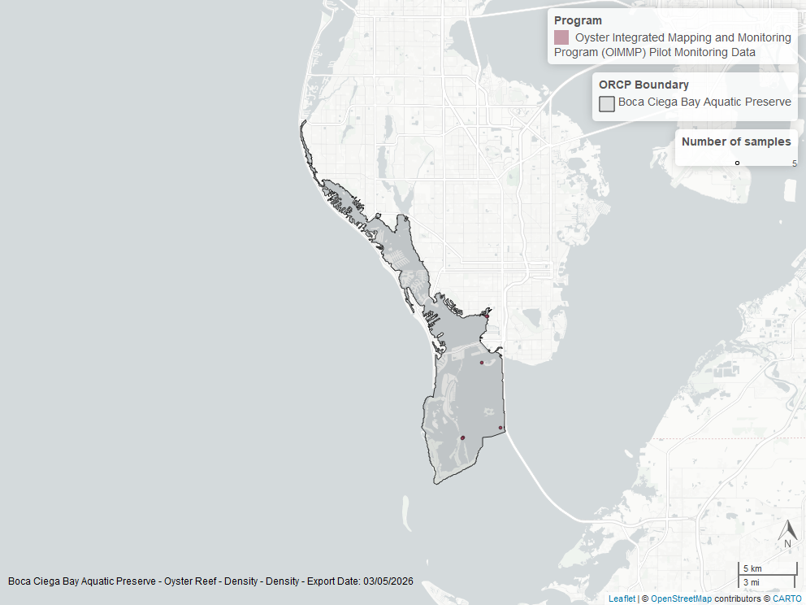

Map showing location of oyster density sampling locations within the boundaries of *Boca Ciega Bay Aquatic Preserve*. The bubble size on the maps above reflect the amount of data available at each sampling site.

## Percent Live

For natural reefs, there was insufficient data to calculate a trend for percent live cover.

### Natural

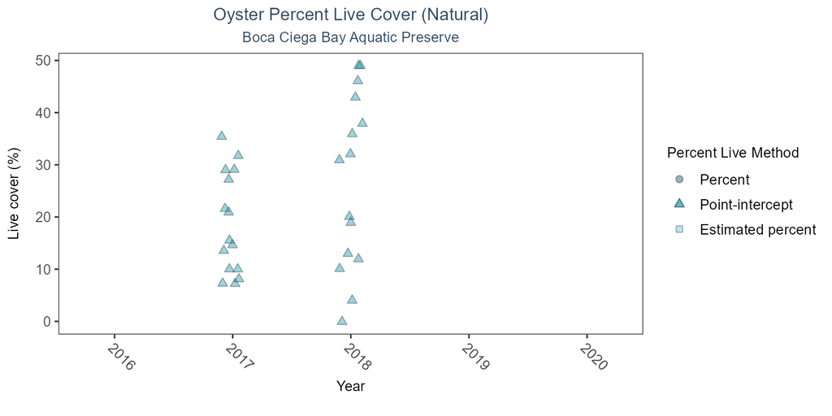

Scatter plot of percent live oysters over time. If the time series included five or more years with observations, an estimated trend (blue line) and a 95% credible interval (purple band) may also be plotted. Estimation method is represented as percent (circles), point-intercept (triangle), or estimated percent (square), with data points jittered horizontally to reduce overlap.

Model results for Oyster Percent Live - Natural

| Habitat Type | Shell Type | Statistical Trend | Period of Record | Estimate | Standard Error | Credible Interval |
| --- | --- | --- | --- | --- | --- | --- |
| Natural | Live Oysters | Insufficient data | 2017 - 2018 | - | - | - |

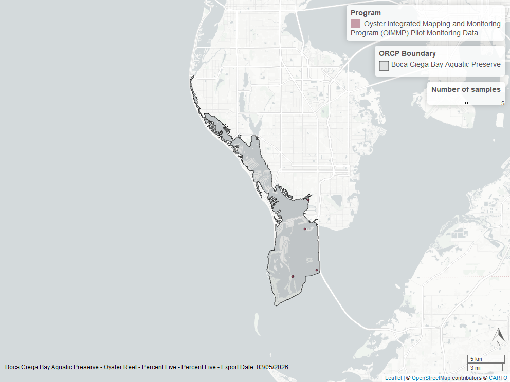

Map showing location of oyster percent live sampling locations within the boundaries of *Boca Ciega Bay Aquatic Preserve*. The bubble size on the maps above reflect the amount of data available at each sampling site.

## Shell Height

For natural reefs, there was insufficient data to calculate a trend for live oysters in either the 25-75mm or the ≥75mm size class.

### Natural

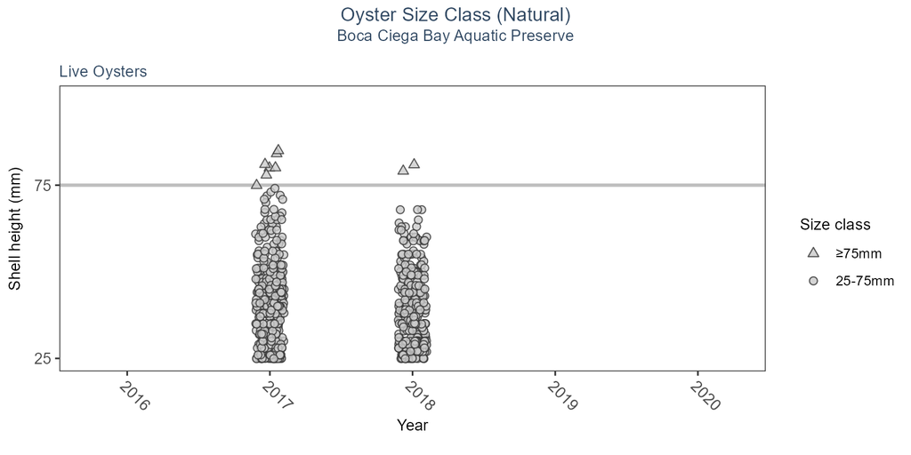

Model results for Oyster Shell Height - Natural

| Habitat Type | Shell Type | SizeClass | Statistical Trend | Period of Record | No. of Samples | Estimate | Standard Error | Credible Interval |
| --- | --- | --- | --- | --- | --- | --- | --- | --- |
| Natural | Live Oysters | >75mm | Insufficient data | 2017 - 2018 | 9 | - | - | - |
| Natural | Live Oysters | 25-75mm | Insufficient data | 2017 - 2018 | 701 | - | - | - |

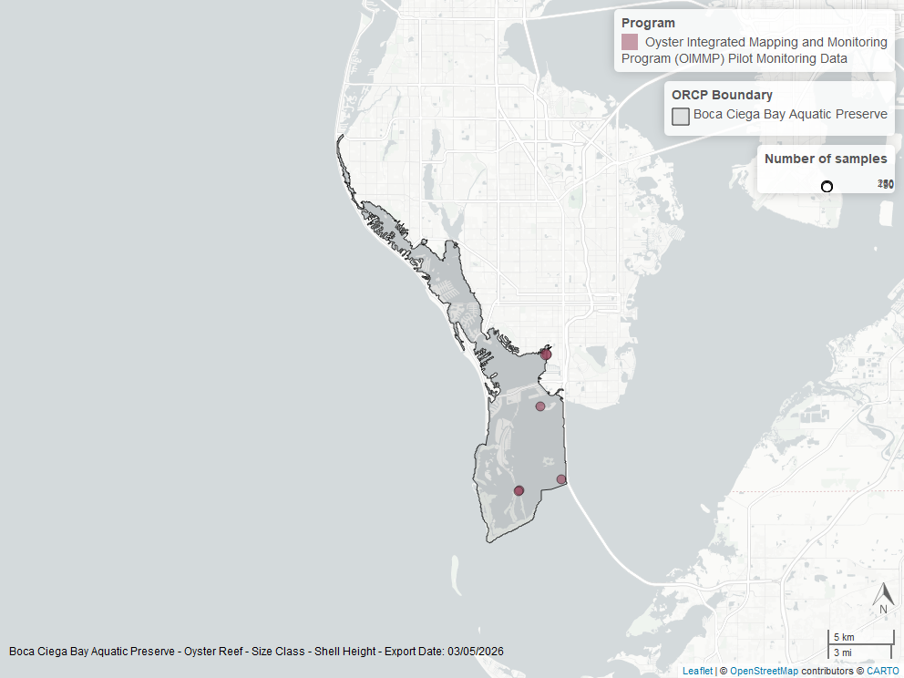

Map showing location of oyster shell height sampling locations within the boundaries of *Boca Ciega Bay Aquatic Preserve*. The bubble size on the maps above reflect the amount of data available at each sampling site.

# Species list

[output not shown]

1 - Submerged Aquatic Vegetation, 2 - Coastal Wetlands, 3 - Nekton

# References

1.

Florida Department of Environmental Protection (DEP). [Florida STORET / WIN](https://data.florida-seacar.org/programs/details/5002). (2024).

2.

U.S. Environmental Protection Agency (EPA). [EPA STOrage and RETrieval Data Warehouse (STORET)/WQX](https://data.florida-seacar.org/programs/details/103). (2023).

3.

U.S. Environmental Protection Agency (EPA); Office of Research and Development. [Environmental Monitoring Assessment Program](https://data.florida-seacar.org/programs/details/115). (2004).

4.

U.S. Environmental Protection Agency (EPA); Office of Water; National Oceanic and Atmospheric Administration (NOAA); U.S. Geological Survey (USGS); U.S. Fish and Wildlife Service (USFWS); National Estuary Program (NEP); coastal states. [National Aquatic Resource Surveys, National Coastal Condition Assessment](https://data.florida-seacar.org/programs/details/118). (2021).

5.

Florida Fish and Wildlife Conservation Commission (FWC). [Fisheries-Independent Monitoring (FIM) Program](https://data.florida-seacar.org/programs/details/69). (2022).

6.

Tampa Bay Estuary Program. [Tampa Bay Benthic Monitoring](https://data.florida-seacar.org/programs/details/4067). (2022).

7.

Florida Fish and Wildlife Conservation Commission (FWC); Florida Fish and Wildlife Research Institute (FWRI). [Harmful Algal Bloom Marine Observation Network](https://data.florida-seacar.org/programs/details/95). (2018).

8.

National Oceanic and Atmospheric Administration (NOAA); Center for Coastal Monitoring and Assessment. [National Status and Trends Mussel Watch](https://data.florida-seacar.org/programs/details/102). (2000).

9.

Pinellas County (Florida); Department of Environmental Management; Tampa Bay Estuary Program (TBEP). [Western Pinellas County Seagrass Monitoring](https://data.florida-seacar.org/programs/details/564). (2019).

10.

Tampa Bay Interagency Seagrass Monitoring Program; Tampa Bay Estuary Program (TBEP). [Tampa Bay Seagrass Monitoring](https://data.florida-seacar.org/programs/details/565). (2023).